# Final Project

December 13, 2020

```r
#clean workspace
rm(list = ls())
```

```r
##load packages
library(mosaic)
library(tidyverse)
library(dplyr)
library(ggplot2)
```

```r
install.packages("multcomp")
library(multcomp)
install.packages("party")
library(party)
```

```r
## load data
metacritic_games <- read.csv("C:/Users/Sarah Petro/OneDrive - The Pennsylvania State University/FinalProject_Stat184/metacritic_games.csv")
vgsales <- read.csv("C:/Users/Sarah Petro/OneDrive - The Pennsylvania State University/FinalProject_Stat184/videogamesales/vgsales.csv")
```

### Research Question:

What video games are the most popular based on critic reviews? This will be based on sale numbers and I also plan to break the popularity down by figuring out which games have the most popular critic score and cross referencing that with sales data to see if high critic score correlates with better sales.

I found the data sets on Kaggle and downloaded the .csv files from the Kaggle website.

### Meta Critic Games

The first data set I used is Video Game Sales 2019 from Kaggle. It was gathered by Andrea Cadeddu who is a user at on Kaggle and can be found at: https://www.kaggle.com/skateddu/metacritic-games-stats-20112019. She gathered this data containing meta critic scores for video games. The data set was last updated in 2019, so it has current game data included to go along with the sales data in the Video Game Sales dataset.

Below, you can see a snippet of the data along with some summary statistics.

```r
head(metacritic_games)
```

|  | game | platform | developer | genre | number_players | rating | release_date | positive_critics | neutral_critics | negative_critics | positive_users | neutral_users | negative_users | metascore | user_score |
| --- | --- | --- | --- | --- | --- | --- | --- | --- | --- | --- | --- | --- | --- | --- | --- |
| 1 | Portal 2 | PC | Valve Software | Action |  | E10+ | Apr 18, 2011 | 51 | 1 | 0 | 1700 | 107 | 19 | 95 | 90 |
| 2 | The Elder Scrolls V: Skyrim | PC | Bethesda Game Studios | Role-Playing | No Online Multiplayer | M | Nov 10, 2011 | 32 | 0 | 0 | 1616 | 322 | 451 | 94 | 82 |
| 3 | The Legend of Zelda: Ocarina of Time 3D | 3DS | GREZZO | Miscellaneous | No Online Multiplayer | E10+ | Jun 19, 2011 | 84 | 1 | 0 | 283 | 20 | 5 | 94 | 90 |
| 4 | Batman: Arkham City | PC | Rocksteady Studios | Action Adventure |  | T | Nov 21, 2011 | 27 | 0 | 0 | 240 | 34 | 27 | 91 | 87 |
| 5 | Super Mario 3D Land | 3DS | Nintendo | Action | No Online Multiplayer | E | Nov 13, 2011 | 81 | 1 | 0 | 251 | 39 | 11 | 90 | 84 |
| 6 | Deus Ex: Human Revolution | PC | Nixxes Software | Action | No Online Multiplayer | M | Aug 23, 2011 | 52 | 0 | 0 | 520 | 112 | 78 | 90 | 85 |

```r
summary(metacritic_games)
```

```
     game             platform          developer
 Length:5699        Length:5699        Length:5699
 Class :character   Class :character   Class :character
 Mode  :character   Mode  :character   Mode  :character



    genre           number_players        rating
 Length:5699        Length:5699        Length:5699
 Class :character   Class :character   Class :character
 Mode  :character   Mode  :character   Mode  :character



 release_date       positive_critics neutral_critics
 Length:5699        Min.   :  0.00   Min.   : 0.000
 Class :character   1st Qu.:  3.00   1st Qu.: 3.000
 Mode  :character   Median :  8.00   Median : 6.000
                    Mean   : 13.35   Mean   : 7.959
                    3rd Qu.: 17.00   3rd Qu.:10.000
                    Max.   :118.00   Max.   :65.000
 negative_critics positive_users    neutral_users
 Min.   : 0.000   Min.   :   0.00   Min.   :  0.000
 1st Qu.: 0.000   1st Qu.:   2.00   1st Qu.:  1.000
 Median : 0.000   Median :   5.00   Median :  2.000
 Mean   : 1.146   Mean   :  28.75   Mean   :  8.637
 3rd Qu.: 1.000   3rd Qu.:  17.00   3rd Qu.:  6.000
 Max.   :51.000   Max.   :2762.00   Max.   :506.000
 negative_users      metascore       user_score
 Min.   :   0.00   Min.   :11.00   Min.   : 1.00
 1st Qu.:   0.00   1st Qu.:66.00   1st Qu.:61.00
 Median :   1.00   Median :73.00   Median :70.00
 Mean   :  14.37   Mean   :71.86   Mean   :67.14
 3rd Qu.:   5.00   3rd Qu.:80.00   3rd Qu.:76.00
 Max.   :2998.00   Max.   :97.00   Max.   :94.00
```

This data set does not have much information on how it was collected and maintained, however it can be assumed she scraped the data from a meta critic score website.  
A case in this dataset describes a video game and its respective critic and user score, whether positive, neutral, or negative. It also includes the platform, genre, and rating.  
I plan to use the game, platform, genre, positive_critics, and negative_critics in conjunction with the other dataset to conclude popular video games and their ratings.

```r
nrow(metacritic_games)
```

```
[1] 5699
```

The dataset has a lot of rows for exploration at 5,699 rows in total.

### Video Game Sales

The second dataset I chose is the Video Game Sales data set. This dataset was collected by Gregory Smith who is a data engineer at Petzl America. This is the second version of the data and has not been updated for 4 years. It can be found at: https://www.kaggle.com/gregorut/videogamesales. I plan to use this dataset as a supplementary data source for the meta critic games dataset by using it to analyze how well rated games sold in both the North American and Global Markets. Below, you can see a snippet of the data and the columns included in the data set.

```r
head(vgsales)
```

|  | Rank | Name | Platform | Year | Genre | Publisher | NA_Sales | EU_Sales | JP_Sales | Other_Sales | Global_Sales |
| --- | --- | --- | --- | --- | --- | --- | --- | --- | --- | --- | --- |
| 1 | 1 | Wii Sports | Wii | 2006 | Sports | Nintendo | 41.49 | 29.02 | 3.77 | 8.46 | 82.74 |
| 2 | 2 | Super Mario Bros. | NES | 1985 | Platform | Nintendo | 29.08 | 3.58 | 6.81 | 0.77 | 40.24 |
| 3 | 3 | Mario Kart Wii | Wii | 2008 | Racing | Nintendo | 15.85 | 12.88 | 3.79 | 3.31 | 35.82 |
| 4 | 4 | Wii Sports Resort | Wii | 2009 | Sports | Nintendo | 15.75 | 11.01 | 3.28 | 2.96 | 33.00 |
| 5 | 5 | Pokemon Red/Pokemon Blue | GB | 1996 | Role-Playing | Nintendo | 11.27 | 8.89 | 10.22 | 1.00 | 31.37 |
| 6 | 6 | Tetris | GB | 1989 | Puzzle | Nintendo | 23.20 | 2.26 | 4.22 | 0.58 | 30.26 |

```r
summary(vgsales)
```

```
      Rank           Name             Platform
 Min.   :    1   Length:16598       Length:16598
 1st Qu.: 4151   Class :character   Class :character
 Median : 8300   Mode  :character   Mode  :character
 Mean   : 8301
 3rd Qu.:12450
 Max.   :16600
     Year              Genre            Publisher
 Length:16598       Length:16598       Length:16598
 Class :character   Class :character   Class :character
 Mode  :character   Mode  :character   Mode  :character



    NA_Sales          EU_Sales          JP_Sales
 Min.   : 0.0000   Min.   : 0.0000   Min.   : 0.00000
 1st Qu.: 0.0000   1st Qu.: 0.0000   1st Qu.: 0.00000
 Median : 0.0800   Median : 0.0200   Median : 0.00000
 Mean   : 0.2647   Mean   : 0.1467   Mean   : 0.07778
 3rd Qu.: 0.2400   3rd Qu.: 0.1100   3rd Qu.: 0.04000
 Max.   :41.4900   Max.   :29.0200   Max.   :10.22000
  Other_Sales        Global_Sales
 Min.   : 0.00000   Min.   : 0.0100
 1st Qu.: 0.00000   1st Qu.: 0.0600
 Median : 0.01000   Median : 0.1700
 Mean   : 0.04806   Mean   : 0.5374
 3rd Qu.: 0.04000   3rd Qu.: 0.4700
 Max.   :10.57000   Max.   :82.7400
```

This dataset was also available in a .csv format from Kaggle which I was able to download and import into RStudio.  
A case in this dataset is the same as the last where one case represents video game sales for a particular video game in the year it was released.  
I plan to use the Name, Platform, Genre, Year, and NA_Sales columns in my data exploration. I plan to use these in conjunction with the Meta Critic Games data set columns.

```r
nrow(vgsales)
```

```
[1] 16598
```

### Informative Plots

With the summary statistics above, I am planning to gauge popularity for the most popular video games by using both critic score and sales.

```r
highest_rank <- which.max(metacritic_games$positive_critics)
highest_rank
```

```
[1] 4513
```

```r
pos <- metacritic_games %>% filter(positive_critics > 100)
pos
```

| game | platform | developer | genre | number_players | rating | release_date | positive_critics | neutral_critics | negative_critics | positive_users | neutral_users | negative_users | metascore | user_score |
| --- | --- | --- | --- | --- | --- | --- | --- | --- | --- | --- | --- | --- | --- | --- |
| Uncharted 4: A Thief's End | PS4 | Naughty Dog | General | Up to 10 | T | May 10, 2016 | 111 | 1 | 1 | 1533 | 148 | 68 | 93 | 84 |
| The Legend of Zelda: Breath of the Wild | Switch | Nintendo | Action Adventure | No Online Multiplayer | E10+ | Mar 3, 2017 | 106 | 3 | 0 | 2762 | 241 | 135 | 97 | 85 |
| Super Mario Odyssey | Switch | Nintendo | Action | No Online Multiplayer | E10+ | Oct 27, 2017 | 113 | 0 | 0 | 977 | 62 | 30 | 97 | 90 |
| Horizon Zero Dawn | PS4 | Guerrilla | Role-Playing | No Online Multiplayer | T | Feb 28, 2017 | 110 | 5 | 0 | 1168 | 117 | 105 | 89 | 83 |
| God of War | PS4 | SCE Santa Monica | Action Adventure | No Online Multiplayer | M | Apr 20, 2018 | 118 | 0 | 0 | 2488 | 109 | 109 | 94 | 91 |
| Marvel's Spider-Man | PS4 | Insomniac Games | Action Adventure | No Online Multiplayer | T | Sep 7, 2018 | 110 | 6 | 0 | 795 | 66 | 44 | 87 | 87 |

By filtering for games that were had more than 100 positiv critic scores, you are left with the 6 most popular games rated by critics.

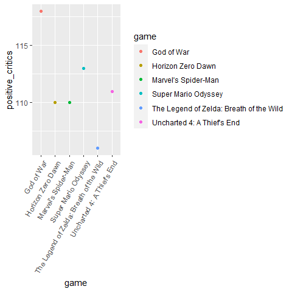

```r
pos %>% ggplot(aes(x = game,y=positive_critics)) + geom_point(aes(color=game)) +
  theme(axis.text.x = element_text(angle = 60, vjust = 1, hjust=1))
```

With this information, we can see how well God of War did in sales:

```r
vgsales.12.4.2019 %>% filter(Name == "God of War")
```

[output not shown]

```r
metacritic_games %>% filter(game == "The Elder Scrolls V: Skyrim")
```

| game | platform | developer | genre | number_players | rating | release_date | positive_critics | neutral_critics | negative_critics | positive_users | neutral_users | negative_users | metascore | user_score |
| --- | --- | --- | --- | --- | --- | --- | --- | --- | --- | --- | --- | --- | --- | --- |
| The Elder Scrolls V: Skyrim | PC | Bethesda Game Studios | Role-Playing | No Online Multiplayer | M | Nov 10, 2011 | 32 | 0 | 0 | 1616 | 322 | 451 | 94 | 82 |
| The Elder Scrolls V: Skyrim | Switch | Bethesda Game Studios, Iron Galaxy Studios | Role-Playing | No Online Multiplayer | M | Nov 17, 2017 | 62 | 1 | 0 | 49 | 5 | 9 | 84 | 82 |

```r
vgsales %>% filter(Name == "The Elder Scrolls V: Skyrim")
```

| Rank | Name | Platform | Year | Genre | Publisher | NA_Sales | EU_Sales | JP_Sales | Other_Sales | Global_Sales |
| --- | --- | --- | --- | --- | --- | --- | --- | --- | --- | --- |
| 76 | The Elder Scrolls V: Skyrim | X360 | 2011 | Role-Playing | Bethesda Softworks | 5.03 | 2.86 | 0.10 | 0.85 | 8.84 |
| 127 | The Elder Scrolls V: Skyrim | PS3 | 2011 | Role-Playing | Bethesda Softworks | 2.55 | 2.71 | 0.25 | 1.05 | 6.56 |
| 311 | The Elder Scrolls V: Skyrim | PC | 2011 | Role-Playing | Bethesda Softworks | 1.15 | 2.09 | 0.00 | 0.64 | 3.88 |

### More Exploratory Analysis

I also decided to join the tables along their name variable.

First, I need to change the variable name in metacritic_games from “game” to “Name” to match the vgsales tables. Also, the games need to be matched by platform.

```r
metacritic_names <- metacritic_games %>% rename(Name = game, Platform = platform)
metacritic_names
```

| Name | Platform | developer | genre | number_players | rating | release_date | positive_critics | neutral_critics | negative_critics | positive_users | neutral_users | negative_users | metascore | user_score |
| --- | --- | --- | --- | --- | --- | --- | --- | --- | --- | --- | --- | --- | --- | --- |
| Portal 2 | PC | Valve Software | Action |  | E10+ | Apr 18, 2011 | 51 | 1 | 0 | 1700 | 107 | 19 | 95 | 90 |
| The Elder Scrolls V: Skyrim | PC | Bethesda Game Studios | Role-Playing | No Online Multiplayer | M | Nov 10, 2011 | 32 | 0 | 0 | 1616 | 322 | 451 | 94 | 82 |
| The Legend of Zelda: Ocarina of Time 3D | 3DS | GREZZO | Miscellaneous | No Online Multiplayer | E10+ | Jun 19, 2011 | 84 | 1 | 0 | 283 | 20 | 5 | 94 | 90 |
| Batman: Arkham City | PC | Rocksteady Studios | Action Adventure |  | T | Nov 21, 2011 | 27 | 0 | 0 | 240 | 34 | 27 | 91 | 87 |
| Super Mario 3D Land | 3DS | Nintendo | Action | No Online Multiplayer | E | Nov 13, 2011 | 81 | 1 | 0 | 251 | 39 | 11 | 90 | 84 |
| Deus Ex: Human Revolution | PC | Nixxes Software | Action | No Online Multiplayer | M | Aug 23, 2011 | 52 | 0 | 0 | 520 | 112 | 78 | 90 | 85 |
| Pushmo | 3DS | Intelligent Systems | Miscellaneous | 1 Player | E | Dec 8, 2011 | 31 | 0 | 0 | 34 | 4 | 2 | 90 | 83 |
| Total War: Shogun 2 | PC | Creative Assembly | Strategy | Online Multiplayer | T | Mar 15, 2011 | 62 | 0 | 0 | 187 | 44 | 29 | 90 | 84 |
| FIFA Soccer 12 | PC | Electronic Arts | Sports |  | E | Sep 27, 2011 | 14 | 0 | 0 | 33 | 8 | 10 | 89 | 71 |
| Battlefield 3 | PC | EA DICE | Action |  | M | Oct 25, 2011 | 60 | 1 | 0 | 1061 | 191 | 271 | 89 | 76 |

[output cut: 990 more lines]

Then, to check the change, you can use colnames()

```r
colnames(metacritic_names)
```

```
 [1] "Name"             "Platform"
 [3] "developer"        "genre"
 [5] "number_players"   "rating"
 [7] "release_date"     "positive_critics"
 [9] "neutral_critics"  "negative_critics"
[11] "positive_users"   "neutral_users"
[13] "negative_users"   "metascore"
[15] "user_score"
```

Finally, the inner join can be completed.

```r
joined <- inner_join(vgsales, metacritic_names, by=c("Name", "Platform"))
joined
```

| Rank | Name | Platform | Year | Genre | Publisher | NA_Sales | EU_Sales | JP_Sales | Other_Sales | Global_Sales | developer | genre | number_players | rating | release_date | positive_critics | neutral_critics | negative_critics | positive_users | neutral_users | negative_users | metascore | user_score |
| --- | --- | --- | --- | --- | --- | --- | --- | --- | --- | --- | --- | --- | --- | --- | --- | --- | --- | --- | --- | --- | --- | --- | --- |
| 43 | Mario Kart 7 | 3DS | 2011 | Racing | Nintendo | 4.74 | 3.91 | 2.67 | 0.89 | 12.21 | Retro Studios, Entertainment Analysis & Development Division | Driving | Up to 8 | E | Dec 4, 2011 | 64 | 9 | 0 | 157 | 45 | 7 | 85 | 83 |
| 45 | Grand Theft Auto V | PS4 | 2014 | Action | Take-Two Interactive | 3.80 | 5.81 | 0.36 | 2.02 | 11.98 | Rockstar North | Action Adventure | Up to 30 | M | Nov 18, 2014 | 66 | 0 | 0 | 369 | 71 | 69 | 97 | 83 |
| 54 | Super Mario 3D Land | 3DS | 2011 | Platform | Nintendo | 4.89 | 2.99 | 2.13 | 0.78 | 10.79 | Nintendo | Action | No Online Multiplayer | E | Nov 13, 2011 | 81 | 1 | 0 | 251 | 39 | 11 | 90 | 84 |
| 65 | New Super Mario Bros. 2 | 3DS | 2012 | Platform | Nintendo | 3.66 | 3.07 | 2.47 | 0.63 | 9.82 | Nintendo | Action | No Online Multiplayer | E | Aug 19, 2012 | 46 | 24 | 0 | 89 | 57 | 24 | 78 | 73 |
| 74 | Animal Crossing: New Leaf | 3DS | 2012 | Simulation | Nintendo | 2.01 | 2.32 | 4.36 | 0.41 | 9.09 | Nintendo | Simulation | Up to 4 | E | Jun 9, 2013 | 64 | 6 | 0 | 142 | 8 | 5 | 88 | 88 |
| 78 | FIFA 16 | PS4 | 2015 | Sports | Electronic Arts | 1.11 | 6.06 | 0.06 | 1.26 | 8.49 | EA Sports | Sports | Up to 22 | E | Sep 22, 2015 | 37 | 5 | 0 | 52 | 24 | 145 | 82 | 44 |
| 94 | Call of Duty: Advanced Warfare | PS4 | 2014 | Shooter | Activision | 2.80 | 3.30 | 0.14 | 1.37 | 7.60 | Sledgehammer Games | Action | Up to 18 | M | Nov 3, 2014 | 35 | 4 | 0 | 166 | 110 | 118 | 83 | 57 |
| 110 | Fallout 4 | PS4 | 2015 | Role-Playing | Bethesda Softworks | 2.47 | 3.15 | 0.24 | 1.10 | 6.96 | Bethesda Game Studios | General | No Online Multiplayer | M | Nov 10, 2015 | 52 | 6 | 0 | 671 | 224 | 208 | 87 | 66 |
| 125 | FIFA 15 | PS4 | 2014 | Sports | Electronic Arts | 0.79 | 4.29 | 0.05 | 1.47 | 6.59 | EA Sports | Sports | Up to 22 | E | Sep 23, 2014 | 40 | 7 | 0 | 73 | 72 | 123 | 82 | 57 |
| 155 | Destiny | PS4 | 2014 | Shooter | Activision | 2.49 | 2.05 | 0.16 | 0.96 | 5.65 | Bungie Software, Bungie | Shooter | Up to 16 | T | Sep 9, 2014 | 60 | 34 | 1 | 775 | 498 | 553 | 76 | 61 |

[output cut: 555 more lines]

I also decided to use create my own function for summing the sales for a particular game. The function takes the sales of the game and then automatically sums all of the sales to make it easier to calculate.

```r
summed <- function(NA_Sales, EU_Sales, JP_Sales, Other_Sales, Global_Sales) {
  salesTotal <- NA_Sales+EU_Sales+JP_Sales+Other_Sales+Global_Sales
  return (salesTotal)
}
```

Then, a representation for how to use it. Here, I inputted sales data for Grand Theft Auto V. Although this is a simple function, the function will be useful for when I need to calculate the total sales for exploratory graphs later in the project.

```r
summed(3.80, 5.81, 0.36, 2.02, 11.98)
```

```
[1] 23.97
```

Finally, as the last part of my exploratory analysis before I get into my graphs, I wanted to explore some of the Genre and NA_Sales data. Since I am exploring the relationship between popularity of the game and critic reviews, sales data can play an important part in that question. Using the spread function, I can examine the table to show how many sales happened for each genre.

```r
joined %>% spread(key = Genre, value = NA_Sales)
```

| Rank | Name | Year | Publisher | EU_Sales | JP_Sales | Other_Sales | Global_Sales | developer | genre | number_players | rating | release_date | positive_critics | neutral_critics | negative_critics | positive_users | neutral_users | negative_users | metascore | user_score | Action | Adventure | Fighting | Misc | Platform | Puzzle | Racing | Role-Playing | Shooter | … |
| --- | --- | --- | --- | --- | --- | --- | --- | --- | --- | --- | --- | --- | --- | --- | --- | --- | --- | --- | --- | --- | --- | --- | --- | --- | --- | --- | --- | --- | --- | --- |
| 43 | Mario Kart 7 | 2011 | Nintendo | 3.91 | 2.67 | 0.89 | 12.21 | Retro Studios, Entertainment Analysis & Development Division | Driving | Up to 8 | E | Dec 4, 2011 | 64 | 9 | 0 | 157 | 45 | 7 | 85 | 83 | NA | NA | NA | NA | NA | NA | 4.74 | NA | NA | … |
| 45 | Grand Theft Auto V | 2014 | Take-Two Interactive | 5.81 | 0.36 | 2.02 | 11.98 | Rockstar North | Action Adventure | Up to 30 | M | Nov 18, 2014 | 66 | 0 | 0 | 369 | 71 | 69 | 97 | 83 | 3.80 | NA | NA | NA | NA | NA | NA | NA | NA | … |
| 54 | Super Mario 3D Land | 2011 | Nintendo | 2.99 | 2.13 | 0.78 | 10.79 | Nintendo | Action | No Online Multiplayer | E | Nov 13, 2011 | 81 | 1 | 0 | 251 | 39 | 11 | 90 | 84 | NA | NA | NA | NA | 4.89 | NA | NA | NA | NA | … |
| 65 | New Super Mario Bros. 2 | 2012 | Nintendo | 3.07 | 2.47 | 0.63 | 9.82 | Nintendo | Action | No Online Multiplayer | E | Aug 19, 2012 | 46 | 24 | 0 | 89 | 57 | 24 | 78 | 73 | NA | NA | NA | NA | 3.66 | NA | NA | NA | NA | … |
| 74 | Animal Crossing: New Leaf | 2012 | Nintendo | 2.32 | 4.36 | 0.41 | 9.09 | Nintendo | Simulation | Up to 4 | E | Jun 9, 2013 | 64 | 6 | 0 | 142 | 8 | 5 | 88 | 88 | NA | NA | NA | NA | NA | NA | NA | NA | NA | … |
| 78 | FIFA 16 | 2015 | Electronic Arts | 6.06 | 0.06 | 1.26 | 8.49 | EA Sports | Sports | Up to 22 | E | Sep 22, 2015 | 37 | 5 | 0 | 52 | 24 | 145 | 82 | 44 | NA | NA | NA | NA | NA | NA | NA | NA | NA | … |
| 94 | Call of Duty: Advanced Warfare | 2014 | Activision | 3.30 | 0.14 | 1.37 | 7.60 | Sledgehammer Games | Action | Up to 18 | M | Nov 3, 2014 | 35 | 4 | 0 | 166 | 110 | 118 | 83 | 57 | NA | NA | NA | NA | NA | NA | NA | NA | 2.80 | … |
| 110 | Fallout 4 | 2015 | Bethesda Softworks | 3.15 | 0.24 | 1.10 | 6.96 | Bethesda Game Studios | General | No Online Multiplayer | M | Nov 10, 2015 | 52 | 6 | 0 | 671 | 224 | 208 | 87 | 66 | NA | NA | NA | NA | NA | NA | NA | 2.47 | NA | … |
| 125 | FIFA 15 | 2014 | Electronic Arts | 4.29 | 0.05 | 1.47 | 6.59 | EA Sports | Sports | Up to 22 | E | Sep 23, 2014 | 40 | 7 | 0 | 73 | 72 | 123 | 82 | 57 | NA | NA | NA | NA | NA | NA | NA | NA | NA | … |
| 155 | Destiny | 2014 | Activision | 2.05 | 0.16 | 0.96 | 5.65 | Bungie Software, Bungie | Shooter | Up to 16 | T | Sep 9, 2014 | 60 | 34 | 1 | 775 | 498 | 553 | 76 | 61 | NA | NA | NA | NA | NA | NA | NA | NA | 2.49 | … |

[output cut: 555 more lines]

### Graphs of the Data

Graphs are an important visualization tool for examining relationships between data. For my first graph, I will be looking at the relationship between user score and meta score. As well I added color mapped to positive critics and size mapped to negative critics so that all of the scored information and their correlations can be viewed.

```
Ignoring unknown aesthetics: stat
```

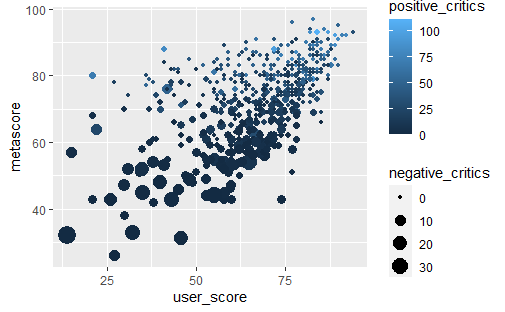

```r
joined %>% ggplot(aes(x=user_score, y=metascore)) +
  geom_point(aes(color = positive_critics,stat = "identity", size = negative_critics))
```

Adding onto this graph, I decided to look at the cluster of points for high number of positive critics vs meta score along with an overlay of a smooth density line. I also used color to showcase user score as well to showcase the same amount of information of distribution of user score.

```
Ignoring unknown aesthetics: stat
```

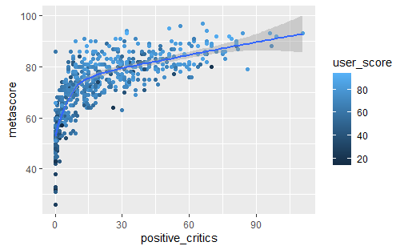

```r
joined %>% ggplot(aes(x=positive_critics, y=metascore)) +
  geom_point(aes(color = user_score, stat = "identity")) + stat_smooth()
```

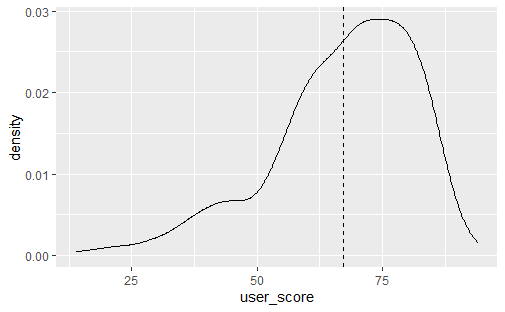

```r
joined %>% ggplot(aes(x=user_score)) +
  geom_density() + geom_vline(aes(xintercept = mean(user_score)), linetype = 2)
```

Finally, I look to use sales data to see how the top 5 selling games are represented in user score. First, I need to filter to find the top selling games. For the sake of simplicity, I am only going to use Global Sales.

```r
highSelling <-  rank(-joined$Global_Sales)
head(joined[order(joined$Rank),],5)
```

|  | Rank | Name | Platform | Year | Genre | Publisher | NA_Sales | EU_Sales | JP_Sales | Other_Sales | Global_Sales | developer | genre | number_players | rating | release_date | positive_critics | neutral_critics | negative_critics | positive_users | neutral_users | negative_users | metascore | user_score |
| --- | --- | --- | --- | --- | --- | --- | --- | --- | --- | --- | --- | --- | --- | --- | --- | --- | --- | --- | --- | --- | --- | --- | --- | --- |
| 1 | 43 | Mario Kart 7 | 3DS | 2011 | Racing | Nintendo | 4.74 | 3.91 | 2.67 | 0.89 | 12.21 | Retro Studios, Entertainment Analysis & Development Division | Driving | Up to 8 | E | Dec 4, 2011 | 64 | 9 | 0 | 157 | 45 | 7 | 85 | 83 |
| 2 | 45 | Grand Theft Auto V | PS4 | 2014 | Action | Take-Two Interactive | 3.80 | 5.81 | 0.36 | 2.02 | 11.98 | Rockstar North | Action Adventure | Up to 30 | M | Nov 18, 2014 | 66 | 0 | 0 | 369 | 71 | 69 | 97 | 83 |
| 3 | 54 | Super Mario 3D Land | 3DS | 2011 | Platform | Nintendo | 4.89 | 2.99 | 2.13 | 0.78 | 10.79 | Nintendo | Action | No Online Multiplayer | E | Nov 13, 2011 | 81 | 1 | 0 | 251 | 39 | 11 | 90 | 84 |
| 4 | 65 | New Super Mario Bros. 2 | 3DS | 2012 | Platform | Nintendo | 3.66 | 3.07 | 2.47 | 0.63 | 9.82 | Nintendo | Action | No Online Multiplayer | E | Aug 19, 2012 | 46 | 24 | 0 | 89 | 57 | 24 | 78 | 73 |
| 5 | 74 | Animal Crossing: New Leaf | 3DS | 2012 | Simulation | Nintendo | 2.01 | 2.32 | 4.36 | 0.41 | 9.09 | Nintendo | Simulation | Up to 4 | E | Jun 9, 2013 | 64 | 6 | 0 | 142 | 8 | 5 | 88 | 88 |

Now that we have the 5 top selling games from Global Sales, we can use this information to draw a few conclusions.